# Practical 4: Regression

Nina van Gerwen (1860852)

6th of October, 2022

```r
library(ISLR)
library(MASS)
library(tidyverse)
```

## Regression

### 1) Creating a linear model

```r
lm_ses <- lm(medv ~ lstat, data = Boston)
```

### 2) Extracting coefficients

```r
coef(lm_ses)
```

```
## (Intercept)       lstat
##  34.5538409  -0.9500494
```

The coefficient of the slope is -0.95. This means that the median value of owner-occupied homes in 1000 dollars decreases by -0.95 for every 1 value increase in the percentage of lower status of the population.

### 3) Summarizing a linear model

```r
summary(lm_ses)
```

```
##
## Call:
## lm(formula = medv ~ lstat, data = Boston)
##
## Residuals:
##     Min      1Q  Median      3Q     Max
## -15.168  -3.990  -1.318   2.034  24.500
##
## Coefficients:
##             Estimate Std. Error t value Pr(>|t|)
## (Intercept) 34.55384    0.56263   61.41   <2e-16 ***
## lstat       -0.95005    0.03873  -24.53   <2e-16 ***
## ---
## Signif. codes:  0 '***' 0.001 '**' 0.01 '*' 0.05 '.' 0.1 ' ' 1
##
## Residual standard error: 6.216 on 504 degrees of freedom
## Multiple R-squared:  0.5441, Adjusted R-squared:  0.5432
## F-statistic: 601.6 on 1 and 504 DF,  p-value: < 2.2e-16
```

The summary command shows the intercepts, their standardd error and whether they are significant. Furthermore, it also shows how much variance is explained in medv by lstat and whether the whole model is significant through an F-test.

### 4) Getting predicted values

```r
y_pred <- predict(lm_ses)
```

### 5) Scatterplot of the data

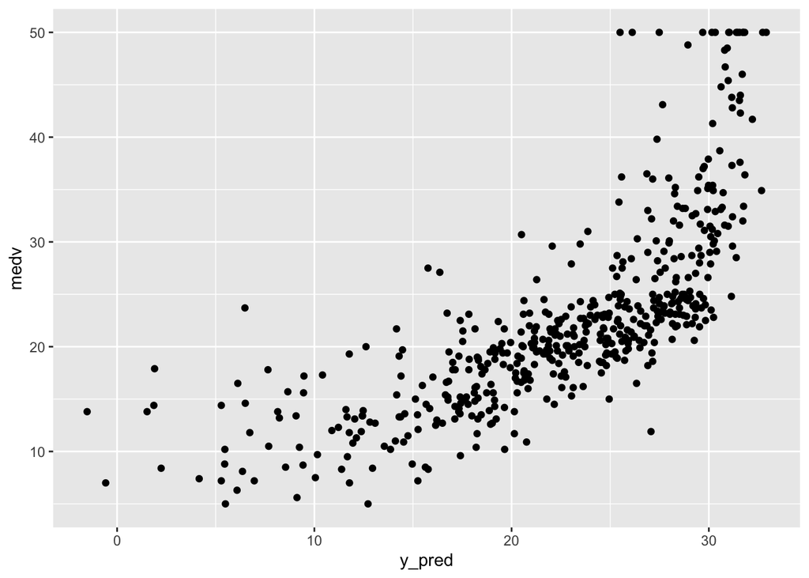

```r
Boston %>%
  mutate(y_pred = y_pred) %>%
  ggplot(data = ., aes(x = y_pred, y = medv)) +
  geom_point()
```

If the fit were perfect, the y_pred values would be identical to the medv values. In other words, the scatterplot would be a straight line with formula: medv = 1 *y_pred

### 6) Creating a vector of spaced values

```r
pred_dat <- seq(from = 0, to = 40, by = (40/999)) %>%
  data.frame(lstat = .)
```

### 7) Creating newly predicted data

```r
y_pred_new <- predict(lm_ses, newdata = pred_dat)
```

### 8) Another scatter plot

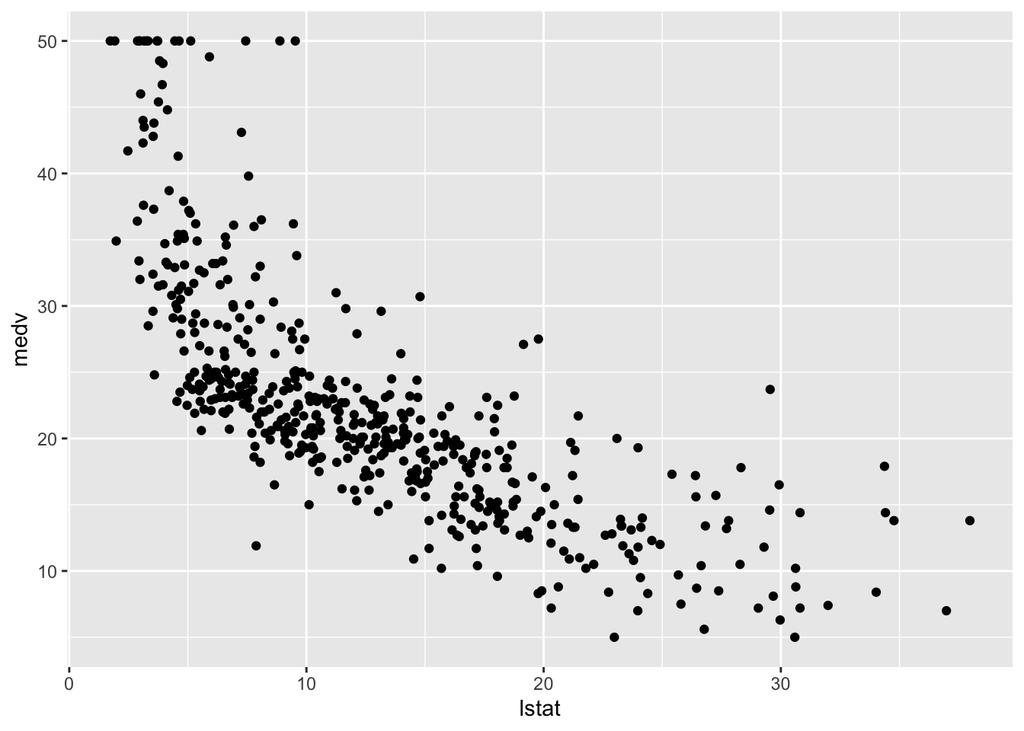

```r
p_scatter <- Boston %>%
  ggplot(data = ., aes(x = lstat, y = medv)) +
  geom_point()

p_scatter
```

### 9 + 10) Adding a prediction line

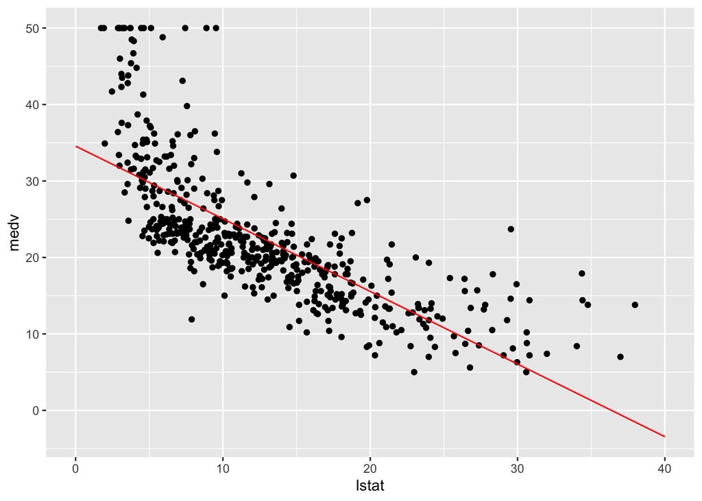

```r
## Q9
pred_dat$medv <- y_pred_new

## Q10
p_scatter <- p_scatter +
  geom_line(data = pred_dat, col = "red")

p_scatter
```

The line represents the regression formula.

### 11) Gaining confidence intervals

```r
y_pred_95 <- predict(lm_ses, newdata = pred_dat, interval = "confidence")
```

In this object you have: the predicted values, the lower and the upper bound of their 95% confidence interval (i.e., a form of their uncertainty).

### 12) New data frame

```r
pred_dat <- data.frame(medv = pred_dat$medv, lstat = pred_dat$lstat,
                       lower = y_pred_95[, 2], upper = y_pred_95[, 3])
```

### 13) Adding a ribbon

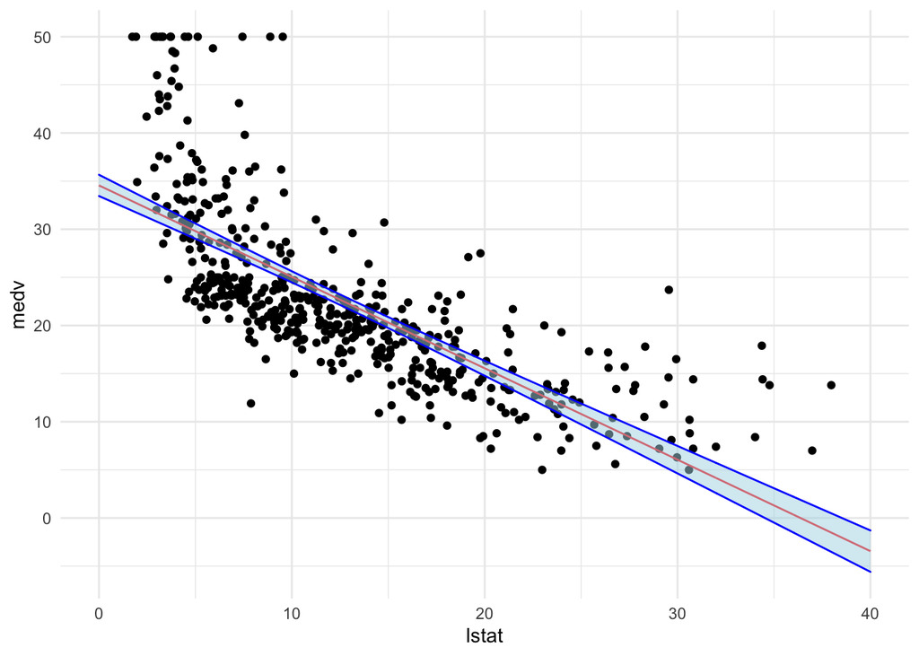

```r
p_scatter <- p_scatter +
  geom_ribbon(data = pred_dat, aes(x = lstat, ymin = lower, ymax = upper),
              alpha = .5, fill = "lightblue", col = "blue") +
  theme_minimal()

p_scatter
```

### 14) The ribbon

The geom_ribbon() argument shows the 95% confidence interval for the regression line. In other words, if you were to repeat the sampling 100 times, 95% of the time the confidence interval will contain the true value (i.e., medv).

### 15) Repeating but with prediction

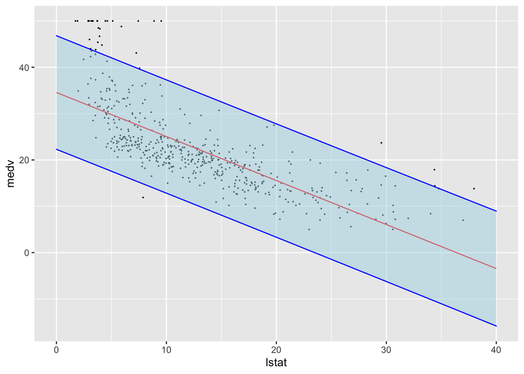

```r
pred_repeat <- predict(lm_ses, newdata = pred_dat, interval = "prediction")

repeat_data <- data.frame(medv = pred_dat$medv, lstat = pred_dat$lstat,
           lower = pred_repeat[, 2], upper = pred_repeat[, 3])

Boston %>%
  ggplot(data = ., aes(x = lstat, y = medv)) +
  geom_point(size = .1) +
  geom_line(data = repeat_data, col = "red") +
  geom_ribbon(data = repeat_data, aes(x = lstat, ymin = lower,
                                      ymax = upper),
              alpha = .5, fill = "lightblue", col = "blue")
```

This new plot shows the 95% prediction interval for the regression line. This means that if u were to get 100 new observation, 95 of them would fall within the blue lines.

## Mean Squared Error

### 16) Mean Squared Error function

```r
mse <- function(y_true, y_pred){
  MSE <- mean((y_true - y_pred)^2, na.rm = TRUE)
  return(MSE)
}
```

### 17) Testing the function

```r
mse(1:10, 10:1)
```

```
## [1] 33
```

Eureka! It works.

### 18) Calculating MSE

```r
mse(Boston$medv, predict(lm_ses))
```

```
## [1] 38.48297
```

The mean squared error of the regression model is 38.48.

## Train-validation-test split

### 19) New vector

```r
splits <- c(rep("train", 253), rep("validation", 152), rep("test", 101))
```

### 20) Sampling it to the Boston dataset

```r
set.seed(1248)

boston_master <- Boston %>%
  mutate(splits = sample(splits))
```

### 21) Separating the data into three

```r
boston_train <- Boston %>% filter(., splits == "train")
boston_valid <- Boston %>% filter(., splits == "validation")
boston_test <- Boston %>% filter(., splits == "test")
```

### 22) Training model

```r
model_1 <- lm(medv ~ lstat, data = boston_train)

summary(model_1)
```

```
##
## Call:
## lm(formula = medv ~ lstat, data = boston_train)
##
## Residuals:
##    Min     1Q Median     3Q    Max
## -8.316 -4.083 -1.521  2.246 19.455
##
## Coefficients:
##             Estimate Std. Error t value Pr(>|t|)
## (Intercept) 34.82836    0.75614   46.06   <2e-16 ***
## lstat       -0.92514    0.05798  -15.96   <2e-16 ***
## ---
## Signif. codes:  0 '***' 0.001 '**' 0.01 '*' 0.05 '.' 0.1 ' ' 1
##
## Residual standard error: 5.887 on 251 degrees of freedom
## Multiple R-squared:  0.5036, Adjusted R-squared:  0.5016
## F-statistic: 254.6 on 1 and 251 DF,  p-value: < 2.2e-16
```

### 23) Calculating MSE on training set

```r
model_1_mse_train <- mse(boston_train$medv, predict(model_1))
```

### 24) Calculating MSE on validation set

```r
model_1_mse_valid <- mse(boston_valid$medv, predict(model_1,
                                                    newdata = boston_valid))
```

### 25) Second LM model and MSE calculations

```r
model_2 <- lm(medv ~ lstat + age + tax, data = boston_train)

model_2_mse_train <- mse(boston_train$medv, predict(model_2))

model_2_mse_validation <- mse(boston_valid$medv, predict(model_2,
                                                         newdata = boston_valid))
```

### 26) Comparing the models

Model 1 has a higher training MSE than model 2. But the valid MSE of Model 1 is lower than in Model 2. Furthermore, Model 1 is also more parsimonious. Therefore, I would choose model 1 between the two.

### 27) MSE for test

```r
model_1_mse_test <- mse(boston_test$medv, predict(model_1,
                                                  newdata = boston_test))
```

The MSE for the test data is 23.96, which is a good estimate of the Bayes Error (assuming that the test set is like the intended prediction situation).

## Cross-Validation

### 28 + 29) Programming a k-fold cross validation for linear models

```r
cross_valid <- function(formula, dataset, k){
  require(dplyr)
  ## First, the data should be shuffled,, done in the following way
  dataset <- dataset[sample(nrow(dataset)) ,]
  ## Then, the dataset should have an indicator variable for k subsamples
  dataset <- dataset %>%
    mutate(., fold = cut(1:nrow(dataset), breaks = k,
                                labels = 1:k))
  ## Create space for the mse values
  mse <- rep(NA, k)
  ## We want the function to calculate the mse k times, so we use a for loop
  ## In each loop:
  for(i in 1:k){
    ## First, we split the dataset in a training and validation set
    train_data <- dataset %>% filter(fold != i)
    valid_data <- dataset %>% filter(fold == i)

    ## Then, we train the model in the training set
    test_lm <- lm(formula = formula, data = train_data)

    ## Then, we get the outcome name (this was taken from your code)
    outcome_name <- as.character(formula)[2]

    ## Finally, we calculate the mse value using the trained set on our
    ## validation set and put this in the ith element
    mse[i] <- mse(valid_data[[outcome_name]],
                  predict(test_lm, newdata = valid_data))
  }
  ## Finally, we calculate the mean of all mses and return this value
  M_MSE <- mean(mse)
  return(M_MSE)
}

set.seed(1248)
cross_valid(medv ~ lstat + age + tax, dataset = Boston, k = 9)
```

```
## [1] 38.13942
```

```r
cross_valid(medv ~ lstat + I(lstat^2) + age + tax, dataset = Boston, k = 9)
```

```
## [1] 28.18902
```